# 5 practical ways to improve your R project

Scottish Government R User Day

Alice Byers

Data Division, Scottish Government

6 December 2023

## Disclaimer

- Opinion based on experience
- One size doesn’t fit all

# 1. RStudio Projects

## Why?

- Keeps all related files together in one folder
- Sets working directory so file paths can be relative to project
- Facilitates use of RStudio Git integration

[Posit Support: Using RStudio Projects](https://support.posit.co/hc/en-us/articles/200526207-Using-RStudio-Projects)

## How to create an RStudio project

- In RStudio, go to File -> New Project…
- Create a new project or add a project to an existing directory

[figure not shown]

[Posit Support: Using RStudio Projects](https://support.posit.co/hc/en-us/articles/200526207-Using-RStudio-Projects)

## Opening an RStudio Project

- Creating an RStudio Project adds an `.Rproj` file to your directory

  ```r
  my-project/
  └── my-project.Rproj
  ```

- Open this file to open your project in RStudio
- Working directory automatically set to location of `my-project.Rproj`
- The ‘Files’ pane in RStudio will show your project directory

[Posit Support: Using RStudio Projects](https://support.posit.co/hc/en-us/articles/200526207-Using-RStudio-Projects)

## Opening an RStudio Project

[figure not shown]

[Posit Support: Using RStudio Projects](https://support.posit.co/hc/en-us/articles/200526207-Using-RStudio-Projects)

## Folder structure

- Where possible, store all files related to your project within your RStudio Project directory

  ```r
  my-project/
      ├── code/
      ├── functions/
      ├── data/
      ├── lookups/
      ├── outputs/
      └── my-project.Rproj
  ```

[Duck book: Structuring your project](https://best-practice-and-impact.github.io/qa-of-code-guidance/project_structure.html)

## Relative file paths

- Absolute file paths are difficult to manage and are likely to break if you move your project to a different folder or ask somebody else to run your code.

  ```r
  "C:/Documents/Alice's Folder/my-project/data/"
  ```

- Use the [here package](https://here.r-lib.org/) to write file paths relative to your project directory.

  ```r
  here::here("data")

  here::here("outputs", "2023")
  ```

[Why should I use the here package?](https://malco.io/articles/2018-11-05-why-should-i-use-the-here-package-when-i-m-already-using-projects)

# 2. Use a setup script

## Why?

- Loading all packages in one place makes it easy to see what is required to run the code
- Defining all variables / parameters in one place reduces the number of places in the code you need to edit to make a change

## Example

```r
# Read in data for current and previous year

schools <- readr::read_csv(
   here::here("data", "2023-03-31_schools.csv")
)

library(readr)

schools_prev <- read_csv(
   here::here("data", "2022-03-31_schools.csv")
)
```

## Example - Setup script

```
00_setup.R
```

```r
# Load packages ----

library(here)
library(readr)
library(lubridate)

# Set parameters ----

month_end <- ymd("2023-03-31")

prev_year <- month_end - years(1)
```

## Example - Sourcing setup script

```
01_read-data.R
```

```r
# Run setup script ----

source(here::here("code", "00_setup.R"))

# Read in data for current and previous year ----

schools <- read_csv(
   here("data", paste0(month_end, "_schools.csv"))
)

schools_prev <- read_csv(
   here("data", paste0(prev_year, "_schools.csv"))
)
```

# 3. Code style

## Why?

- Makes code easier to write
- Makes code easier to understand
- Makes code easier to debug

## Tidyverse style guide

- https://style.tidyverse.org/
  - Naming files
  - Naming objects
  - Spacing
  - Using pipes (`%>%`)
  - and lots more

## Example

- Bad practice:

```r
do_something_very_complicated(something="that",requires=many,arguments="some of which may be long")
```

- Good practice:

  ```r
  do_something_very_complicated(
    something = "that",
    requires = many,
    arguments = "some of which may be long"
  )
  ```

## lintr

[lintr](https://lintr.r-lib.org/) runs style checks on existing code and reports back any issues (but doesn’t change any of your code).

```
code.R
```

```r
do_something_very_complicated(something="that",requires=many,arguments="some of which may be long")
```

```r
lintr::lint("code.R")
```

```r
[infix_spaces_linter] Put spaces around all infix operators.
[commas_linter] Commas should always have a space after.
[infix_spaces_linter] Put spaces around all infix operators.
[commas_linter] Commas should always have a space after.
[infix_spaces_linter] Put spaces around all infix operators.
[line_length_linter] Lines should not be more than 80 characters.
```

[lintr guidance](https://lintr.r-lib.org/)

## styler

[styler](http://styler.r-lib.org/) re-styles existing code following the tidyverse style guide

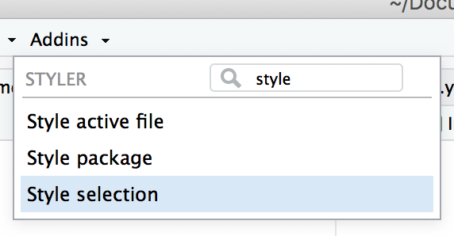

```
code.R
```

```r
do_something_very_complicated(
  something = "that",
  requires = many,
  arguments = "some of which may be long"
)
```

[styler guidance](http://styler.r-lib.org/)

# 4. Code comments

## Why?

- Help somebody else understand the code you’ve written
- Help future you understand the code you’ve written
- Provide context
- Section your code to provide structure and easier navigation

[Duck book: Comments](https://best-practice-and-impact.github.io/qa-of-code-guidance/code_documentation.html#comments)

## How?

- Start a comment line with a single `#` followed by a space

  ```r
  # My first comment
  ```

- Help other people (and yourself in the future) understand how and why the code has been written in a particular way

  ```r
  # Tried solution X, by Y worked better because of Z
  ```

[Duck book: Comments](https://best-practice-and-impact.github.io/qa-of-code-guidance/code_documentation.html#comments)

## What to avoid

- Repeating what is already obvious from the code

  ```r
  # Calculate percentage change
  perc_change <- x / y * 100
  ```

- Hard coded values

  ```r
  perc_change <- x / y * 100
  # 2022: 65%; 2023: 52%
  ```

- Commenting out code to save for later or to be conditionally run

  ```r
  # Uncomment and run in odd numbered years
  # perc_change <- x / y * 100
  ```

[Duck book: Comments](https://best-practice-and-impact.github.io/qa-of-code-guidance/code_documentation.html#comments)

## Code sections

- A comment line followed by at least four dashes (-), equal signs (=), or hash signs (#)

  ```r
  # Section 1 ---------------------------
  ```

- Navigate and fold

[figure not shown]

[figure not shown]

[Posit Support: Code folding and sections](https://support.posit.co/hc/en-us/articles/200484568-Code-Folding-and-Sections-in-the-RStudio-IDE)

# 5. Functions

## Why?

- Minimises repetition
- Simplifies code
- Ensures consistent methods across code
- Easier to maintain

[Duck book: Write re-usable code as functions](https://best-practice-and-impact.github.io/qa-of-code-guidance/modular_code.html#write-re-usable-code-as-functions)

## Example

- Calculating financial year of a date

```
functions/fin_year.R
```

```r
fin_year <- function(date) {
  m <- lubridate::month(date)
  y <- lubridate::year(date)

  ifelse(
    m <= 3,
    paste0(y - 1, "/", y),
    paste0(y, "/", y + 1)
  )
}
```

## Using the function

```r
lubridate::today()
```

```
[1] "2023-12-07"
```

```r
fin_year(lubridate::today())
```

```
[1] "2023/2024"
```

## Using the function in a script

```
code/01_read-data.R
```

```r
# Run setup script ----

source(here::here("code", "00_setup.R"))

# Source functions ----

source(here::here("functions", "fin_year.R"))

# Read in data for current and previous year ----

schools <- read_csv(
   here("data", paste0(fin_year(month_end), "_schools.csv"))
)

schools_prev <- read_csv(
   here("data", paste0(fin_year(prev_year), "_schools.csv"))
)
```

# Summary

1. RStudio Projects
2. Use a setup script
3. Code style
4. Code comments
5. Functions

# Contact

Email: alice.byers@gov.scot

GitHub: [alicebyers5](https://github.com/alicebyers5%3E)

[figure not shown]